# 05_extracthabitat

Michaela Gustafson

1/3/2022

## Extract Habitat Data for Survey Points

In this code I will extract the percentage of each land cover type (which has already been calculated through the focal function ran in the previous script) for each survey point to be added to the environmental variables.

## LIBRARY

These are the packages used in this code:

```r
library(terra)
library(sf)
library(sp)
library(here)
```

```r
library(ggplot2)
library(tidyverse)
library(raster)
library(taRifx)
library(tidyr)
library(dplyr)
library(stringr)
```

## IMPORT LAND COVER RASTERS

```r
# create a list of all .tif files (I know the land cover ones are the only ones listed in my wd)
lc.list <- list.files(here(), pattern = ".tif")
# create a raster stack from the rasters in the list
lc.stack <- raster::stack(lc.list)
```

[output not shown]

[output cut: 8 more lines]

[output not shown]

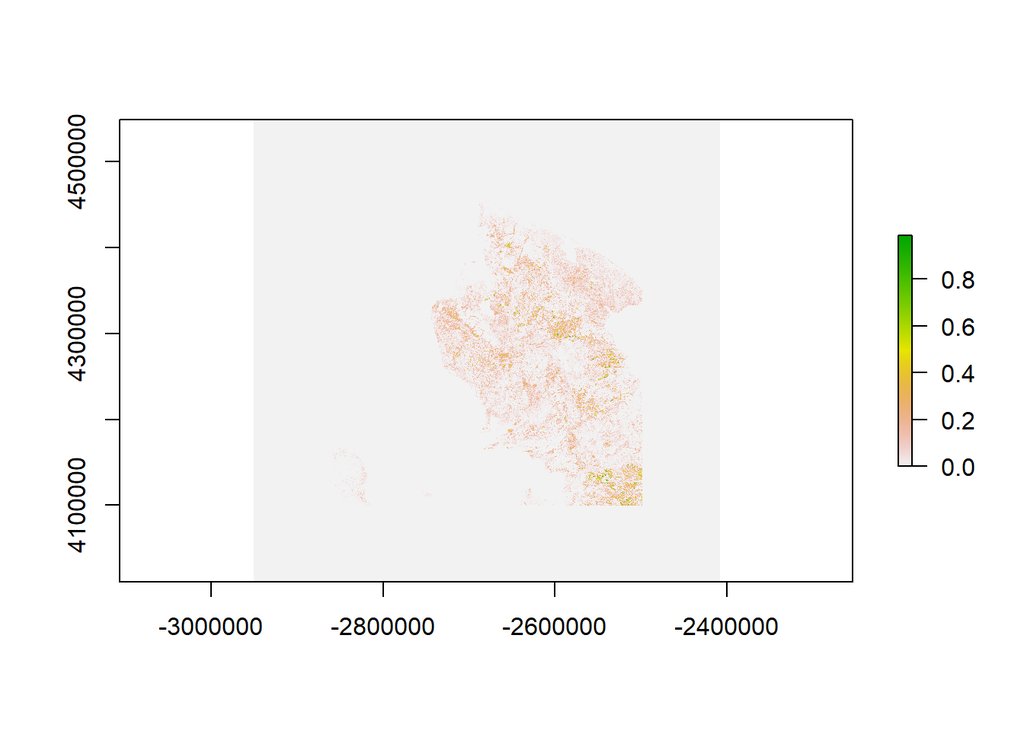

```r
#check
plot(lc.stack[[7]])
```

## IMPORT SURVEY LOCATIONS

2019 survey locations are in lat/lon. 2021 survey locations are in UTMs. I will be converting 2021 points to lat/lon.

### 2019

The recorded lat/lon ended up being in weird locations so I pulled the lat/lon directly from the gps (finalwp_2019.csv) and will be matching the lat/lon waypoints with those recorded in the orignial data sheet (“Point_Count_Env_2019_MG_cleaned.csv”)

In 2019 data, there are points not taken for some survey locations so I will be importing the predetermined lat/lon locations for those from the file imported from the GPS (originalpoints_2019.csv)

At the moment, not sure what I used the backup points for…

```r
points.19 <- read.csv(here("data/Point_Count_Env_2019_MG_cleaned.csv"))
gpx.19 <- read.csv(here("data/finalwp_2019.csv"))
ogpoints.19 <- read.csv("C:/Gyrfalcon/gyrfalcon/data/originalpoints_2019.csv", skip = 22)
backup.19 <- read.csv("C:/Gyrfalcon/gyrfalcon/data/GPS002_2019backup.csv", skip = 22)

# There are extra '1' at the end of the waypoint number names, need to remove them so the key id will match when merging dataframes
backup.19$name = str_remove(backup.19$name, "^0")


# match key id names
gpx.19 <- rename(gpx.19, Waypoint_num = name)
# add leading zero to key id in points.19 to match key id (Waypoint Name)
points.19$Waypoint_num <- str_pad(points.19$Waypoint_num, 3, pad = "0")
# join points and locations from GPS together
points.gpx.join <- left_join(points.19, gpx.19)
# create id key column
points.gpx.join$id <- paste(points.gpx.join$Road_ID, points.gpx.join$UNIT_ID, points.gpx.join$Transect_ID, points.gpx.join$Point_ID, sep = "_")
head(points.gpx.join)
```

```
##   Road_ID UNIT_ID Transect_ID Point_ID Prim_Obs_initials Sec_Obs_Initials
## 1    KOUG       4          19       16                KW               DS
## 2    KOUG       4          19       19                KW               DS
## 3    KOUG       4          19       21                KW               DS
## 4    KOUG       4          19        1                DS               KW
## 5    KOUG       4          19        6                DS               KW
## 6    KOUG       4          19       12                DS               KW
##        Date start_time Temp_F Temp_Celsius Sky Wind Hearing Noise_Distance_m
## 1 10-May-19       6:00     38           NA   0   10       2             1000
## 2 10-May-19       7:07     39           NA   0    8       2             1000
## 3 10-May-19       7:43     38           NA   0   15       3             1000
## 4 11-May-19       5:22     37           NA   0    7       1             1000
## 5 11-May-19       6:17     37           NA   0   12       1             1000
## 6 11-May-19       7:10     38           NA   1   10       1             1000
##   Noise_Direction  Waypoint_num GPS_name                Coordinates       Lat
```

[output cut: 27 more lines]

```r
colnames(points.gpx.join)
```

```
##  [1] "Road_ID"           "UNIT_ID"           "Transect_ID"
##  [4] "Point_ID"          "Prim_Obs_initials" "Sec_Obs_Initials"
##  [7] "Date"              "start_time"        "Temp_F"
## [10] "Temp_Celsius"      "Sky"               "Wind"
## [13] "Hearing"           "Noise_Distance_m"  "Noise_Direction"
## [16] "Waypoint_num"      "GPS_name"          "Coordinates"
## [19] "Lat"               "Long"              "pct_BG"
## [22] "pct_T"             "pct_LS"            "pct_TS"
## [25] "pct_sum"           "Notes"             "X"
## [28] "lon"               "lat"               "ele"
## [31] "time"              "sym"               "type"
## [34] "extensions"        "id"
```

```r
# only keep columns need
points.2019 <- points.gpx.join[,c(35, 28:29)]
head(points.2019)
```

```
##             id lon lat
## 1 KOUG_4_19_16  NA  NA
## 2 KOUG_4_19_19  NA  NA
## 3 KOUG_4_19_21  NA  NA
## 4  KOUG_4_19_1  NA  NA
## 5  KOUG_4_19_6  NA  NA
## 6 KOUG_4_19_12  NA  NA
```

```r
# lat lon are empty because I will be pulling that data in from the correct gpx file or original points file.

# separating out the first 17 surveyed points that don't have matching waypoint
# names in the gps files
missing.points <- points.gpx.join[c(1:17),]

# separate into KOUG and TELL points for naming purposes
miss.points.koug <- missing.points[c(1:11),]
miss.points.tell <- missing.points[c(12:17),]
# Need id names to match those on the points gpx

# Add K or T to column characters respectively so that columns have matching id keys
# and I can bind/join table together
miss.points.koug$UNIT_ID <- paste("K", miss.points.koug$UNIT_ID, sep = "")
miss.points.tell$UNIT_ID <- paste("T", miss.points.tell$UNIT_ID, sep = "")
miss.points.koug$Transect_ID <- paste("T", miss.points.koug$Transect_ID, sep = "")
miss.points.tell$Transect_ID <- paste("T", miss.points.tell$Transect_ID, sep = "")


# bind all points back together into one dataframe
missing.points <- rbind(miss.points.koug, miss.points.tell)

# create the universal id column in the dataframe of missing points
missing.points$name <- paste(missing.points$UNIT_ID, missing.points$Transect_ID, missing.points$Point_ID, sep = "_")

# join the missing points to dataframe to data taken off GPS to get true lat/lon
# for these points
miss.og.point.join <- left_join(missing.points, ogpoints.19, by = "name")


# only keep columns needed and rename them
colnames(miss.og.point.join)
```

```
##  [1] "Road_ID"           "UNIT_ID"           "Transect_ID"
##  [4] "Point_ID"          "Prim_Obs_initials" "Sec_Obs_Initials"
##  [7] "Date"              "start_time"        "Temp_F"
## [10] "Temp_Celsius"      "Sky"               "Wind"
## [13] "Hearing"           "Noise_Distance_m"  "Noise_Direction"
## [16] "Waypoint_num"      "GPS_name"          "Coordinates"
## [19] "Lat"               "Long"              "pct_BG"
## [22] "pct_T"             "pct_LS"            "pct_TS"
## [25] "pct_sum"           "Notes"             "X.x"
## [28] "lon.x"             "lat.x"             "ele.x"
## [31] "time.x"            "sym.x"             "type.x"
## [34] "extensions"        "id"                "name"
## [37] "ID"                "lat.y"             "lon.y"
## [40] "ele.y"             "time.y"            "magvar"
## [43] "geoidheight"       "cmt"               "desc"
## [46] "src"               "sym.y"             "type.y"
## [49] "fix"               "sat"               "hdop"
## [52] "vdop"              "pdop"              "ageofdgpsdata"
## [55] "dgpsid"            "Proximity"         "Temperature"
## [58] "Depth"             "DisplayMode"       "Samples"
## [61] "Expiration"        "CreationTime"      "X.y"
```

```r
miss.og.points <- miss.og.point.join[,c(36, 38,39)]
miss.og.points <- rename(miss.og.points, "lat" = "lat.y")
miss.og.points <- rename(miss.og.points, "lon" = "lon.y")
miss.og.points <- rename(miss.og.points, "id" = "name")


### NEED TO CHANGE Column ID NAMES BACK TO MATCH POINTS 2019

koug.names <- as.data.frame(miss.points.koug$id)
koug.names <- rename(koug.names, 'id' = 'miss.points.koug$id')
tell.names <- as.data.frame(miss.points.tell$id)
tell.names <- rename(tell.names, 'id' = 'miss.points.tell$id')
miss.names <- rbind(koug.names, tell.names)


miss.og.points$id <- miss.names$id
str(miss.og.points)
```

```
## 'data.frame':    17 obs. of  3 variables:
##  $ id : chr  "KOUG_4_19_16" "KOUG_4_19_19" "KOUG_4_19_21" "KOUG_4_19_1" ...
##  $ lat: chr  "64.655344253405929" "64.660403151065111" "64.665461629629135" "64.62888753041625" ...
##  $ lon: chr  "-165.29379095882177" "-165.28198613785207" "-165.27017871849239" "-165.30802611261606" ...
```

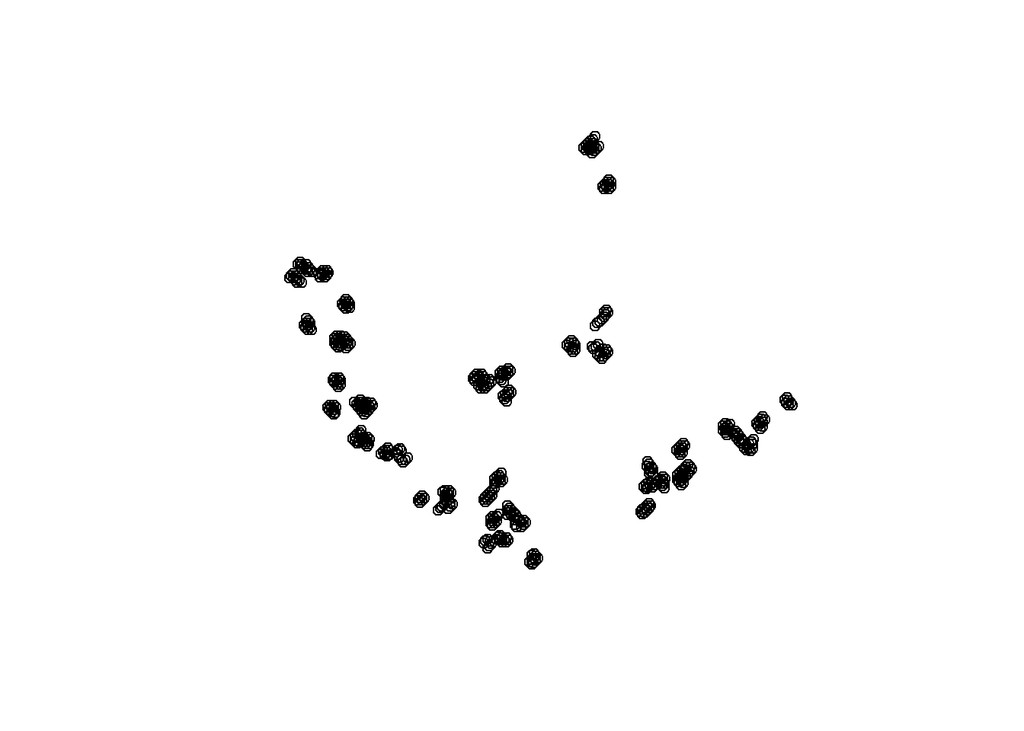

```r
#######################################################################
# remove those incorrect 'missing points' from the dataframe so I can correctly add them in later
points.2019 <- points.2019[complete.cases(points.2019),]

# add corrected points with true lat/lon
points.2019.all <- rbind(miss.og.points, points.2019)

# save CSV of these fixed points and full df for safe keeping
write.csv(points.2019.all, here("data/points_2019_all_FINAL.csv"))

## assign crs
points19.sf <- st_as_sf(points.2019.all,
                        coords = c("lon", "lat"),
                        crs = 4326)

plot(st_geometry(points19.sf))
```

```r
crs(points19.sf)
```

```
## CRS arguments: +proj=longlat +datum=WGS84 +no_defs
```

```r
st_is_valid(points19.sf)
```

[output not shown]

[output cut: 17 more lines]

```r
##############################################################
# reproject points to same crs as hab raster

#st_transform

# 2019 points
points19.proj <- st_transform(points19.sf, crs(lc.stack))
st_crs(points19.proj)
```

```
## Coordinate Reference System:
##   User input: PROJCRS["unknown",
##     BASEGEOGCRS["unknown",
##         DATUM["Unknown_based_on_GRS80_ellipsoid",
##             ELLIPSOID["GRS 1980",6378137,298.257222101004,
##                 LENGTHUNIT["metre",1],
##                 ID["EPSG",7019]]],
##         PRIMEM["Greenwich",0,
##             ANGLEUNIT["degree",0.0174532925199433,
##                 ID["EPSG",9122]]]],
##     CONVERSION["Albers Equal Area",
##         METHOD["Albers Equal Area",
##             ID["EPSG",9822]],
##         PARAMETER["Latitude of false origin",40,
##             ANGLEUNIT["degree",0.0174532925199433],
##             ID["EPSG",8821]],
##         PARAMETER["Longitude of false origin",-96,
##             ANGLEUNIT["degree",0.0174532925199433],
##             ID["EPSG",8822]],
##         PARAMETER["Latitude of 1st standard parallel",50,
##             ANGLEUNIT["degree",0.0174532925199433],
##             ID["EPSG",8823]],
##         PARAMETER["Latitude of 2nd standard parallel",70,
##             ANGLEUNIT["degree",0.0174532925199433],
##             ID["EPSG",8824]],
##         PARAMETER["Easting at false origin",0,
##             LENGTHUNIT["metre",1],
##             ID["EPSG",8826]],
##         PARAMETER["Northing at false origin",0,
##             LENGTHUNIT["metre",1],
##             ID["EPSG",8827]]],
##     CS[Cartesian,2],
##         AXIS["easting",east,
##             ORDER[1],
##             LENGTHUNIT["metre",1,
##                 ID["EPSG",9001]]],
##         AXIS["northing",north,
##             ORDER[2],
##             LENGTHUNIT["metre",1,
##                 ID["EPSG",9001]]]]
```

[output cut: 25 more lines]

```
##         PARAMETER["Easting at false origin",0,
##             LENGTHUNIT["metre",1],
##             ID["EPSG",8826]],
##         PARAMETER["Northing at false origin",0,
##             LENGTHUNIT["metre",1],
##             ID["EPSG",8827]]],
##     CS[Cartesian,2],
##         AXIS["easting",east,
##             ORDER[1],
##             LENGTHUNIT["metre",1,
##                 ID["EPSG",9001]]],
##         AXIS["northing",north,
##             ORDER[2],
##             LENGTHUNIT["metre",1,
##                 ID["EPSG",9001]]]]
```

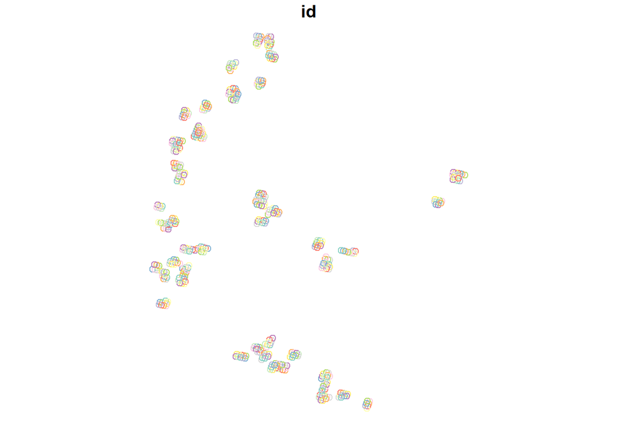

```r
plot(points19.proj)
```

### 2021

```r
points.21 <- read.csv(here("data/Point_Count_Env_2021_MG.csv"))
head(points.21); dim(points.21)
```

```
##   ROAD_ID UNIT_ID TRANSECT_ID POINT_ID PRIM_OBS SEC_OBS SURVEY_DATE START_TIME
## 1    KOUG      K4         T25       19       KW      MG    5-May-21       5:52
## 2    KOUG      K4         T25       23       KW      MG    5-May-21       6:34
## 3    KOUG      K4         T25       20       KW      MG    5-May-21       7:10
## 4    KOUG      K4         T25       24       KW      MG    5-May-21       7:42
## 5    KOUG      K4         T25       21       KW      MG    5-May-21       8:20
## 6    KOUG      K4         T25       12       KW      MG    5-May-21       9:02
##   TEMP_F TEMP_C SKY WIND WIND_DIRECTION HEARING NOISE_DISTANCE_m
## 1   21.0     NA   0    3              N       0               NA
## 2   20.5     NA   0    4              N       0               NA
## 3   23.0     NA   0    1              N       0               NA
## 4   31.0     NA   0    1              N       0               NA
## 5   36.7     NA   0    1              N       0               NA
## 6   44.0     NA   0    0           <NA>       0               NA
##   NOISE_DIRECTION WAYPOINT GPS_NAME   UTM1    UTM2 ELEVATION pct_BG pct_T
## 1            <NA>        1        3 489936 7184190        NA     10    35
## 2            <NA>        2        3 489431 7184820        NA      0    60
## 3            <NA>        3        3 488866 7184259        NA      0    55
## 4            <NA>        4        3 488363 7184890        NA      0    90
## 5            <NA>        5        3 487797 7184330        NA      0   100
## 6            <NA>        6        3 487736 7183134        NA     60    40
##   pct_LS pct_TS                                             NOTES
## 1     55      0                            Ground covered in snow
## 2     40      0                            Ground covered in snow
## 3     45      0 Ground covered in snow; in a small drainage/creek
## 4     10      0                            Ground covered in snow
## 5      0      0                            Ground covered in snow
## 6      0      0
```

```
## [1] 449  26
```

```r
# subset id and utms
colnames(points.21)
```

```
##  [1] "ROAD_ID"          "UNIT_ID"          "TRANSECT_ID"      "POINT_ID"
##  [5] "PRIM_OBS"         "SEC_OBS"          "SURVEY_DATE"      "START_TIME"
##  [9] "TEMP_F"           "TEMP_C"           "SKY"              "WIND"
## [13] "WIND_DIRECTION"   "HEARING"          "NOISE_DISTANCE_m" "NOISE_DIRECTION"
## [17] "WAYPOINT"         "GPS_NAME"         "UTM1"             "UTM2"
## [21] "ELEVATION"        "pct_BG"           "pct_T"            "pct_LS"
## [25] "pct_TS"           "NOTES"
```

```r
points.21 <- points.21[,c(1:4, 19:20)]
points.21$id <- paste(points.21$ROAD_ID, points.21$UNIT_ID, points.21$TRANSECT_ID, points.21$POINT_ID, sep = "_")

head(points.21)
```

```
##   ROAD_ID UNIT_ID TRANSECT_ID POINT_ID   UTM1    UTM2             id
## 1    KOUG      K4         T25       19 489936 7184190 KOUG_K4_T25_19
## 2    KOUG      K4         T25       23 489431 7184820 KOUG_K4_T25_23
## 3    KOUG      K4         T25       20 488866 7184259 KOUG_K4_T25_20
## 4    KOUG      K4         T25       24 488363 7184890 KOUG_K4_T25_24
## 5    KOUG      K4         T25       21 487797 7184330 KOUG_K4_T25_21
## 6    KOUG      K4         T25       12 487736 7183134 KOUG_K4_T25_12
```

```r
#subset again to keep only final key id and utms
points.21 <- points.21[,c(7, 5:6)]
head(points.21); dim(points.21)
```

```
##               id   UTM1    UTM2
## 1 KOUG_K4_T25_19 489936 7184190
## 2 KOUG_K4_T25_23 489431 7184820
## 3 KOUG_K4_T25_20 488866 7184259
## 4 KOUG_K4_T25_24 488363 7184890
## 5 KOUG_K4_T25_21 487797 7184330
## 6 KOUG_K4_T25_12 487736 7183134
```

```
## [1] 449   3
```

```r
# export for safe keeping
write.csv(points.21, here("data/utms_21_final.csv"))

st_crs(points.21)
```

```
## Coordinate Reference System: NA
```

```r
# need to assign crs
# points were taken in UTM UPS, NAD 83, GRS 80
# epsg code: https://epsg.io/26903

points.21.sf <- st_as_sf(points.21,
                         coords = c("UTM1", "UTM2"),
                         crs = 26903)

st_crs(points.21.sf)
```

```
## Coordinate Reference System:
##   User input: EPSG:26903
##   wkt:
## PROJCRS["NAD83 / UTM zone 3N",
##     BASEGEOGCRS["NAD83",
##         DATUM["North American Datum 1983",
##             ELLIPSOID["GRS 1980",6378137,298.257222101,
##                 LENGTHUNIT["metre",1]]],
##         PRIMEM["Greenwich",0,
##             ANGLEUNIT["degree",0.0174532925199433]],
##         ID["EPSG",4269]],
##     CONVERSION["UTM zone 3N",
##         METHOD["Transverse Mercator",
##             ID["EPSG",9807]],
##         PARAMETER["Latitude of natural origin",0,
##             ANGLEUNIT["degree",0.0174532925199433],
##             ID["EPSG",8801]],
##         PARAMETER["Longitude of natural origin",-165,
##             ANGLEUNIT["degree",0.0174532925199433],
##             ID["EPSG",8802]],
##         PARAMETER["Scale factor at natural origin",0.9996,
##             SCALEUNIT["unity",1],
##             ID["EPSG",8805]],
##         PARAMETER["False easting",500000,
##             LENGTHUNIT["metre",1],
##             ID["EPSG",8806]],
##         PARAMETER["False northing",0,
##             LENGTHUNIT["metre",1],
##             ID["EPSG",8807]]],
##     CS[Cartesian,2],
##         AXIS["(E)",east,
##             ORDER[1],
##             LENGTHUNIT["metre",1]],
##         AXIS["(N)",north,
##             ORDER[2],
##             LENGTHUNIT["metre",1]],
##     USAGE[
##         SCOPE["Engineering survey, topographic mapping."],
##         AREA["United States (USA) - between 168Â°W and 162Â°W - Alaska and offshore continental shelf (OCS)."],
##         BBOX[49.52,-168,74.29,-161.99]],
##     ID["EPSG",26903]]
```

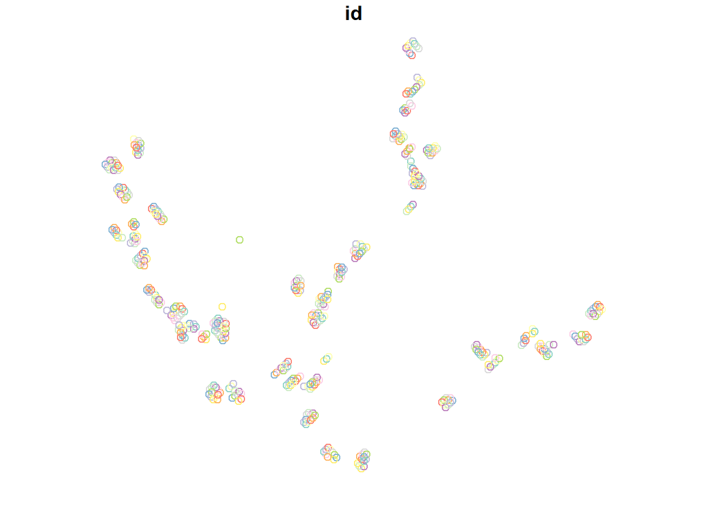

```r
plot(points.21.sf)
```

```r
st_is_valid(points.21.sf)
```

[output not shown]

```r
# reproject 2021 points to match hab raster crs
points21.proj <- st_transform(points.21.sf, crs(lc.stack))
st_crs(points21.proj)
```

```
## Coordinate Reference System:
##   User input: PROJCRS["unknown",
##     BASEGEOGCRS["unknown",
##         DATUM["Unknown_based_on_GRS80_ellipsoid",
##             ELLIPSOID["GRS 1980",6378137,298.257222101004,
##                 LENGTHUNIT["metre",1],
##                 ID["EPSG",7019]]],
##         PRIMEM["Greenwich",0,
##             ANGLEUNIT["degree",0.0174532925199433,
##                 ID["EPSG",9122]]]],
##     CONVERSION["Albers Equal Area",
##         METHOD["Albers Equal Area",
##             ID["EPSG",9822]],
##         PARAMETER["Latitude of false origin",40,
##             ANGLEUNIT["degree",0.0174532925199433],
##             ID["EPSG",8821]],
##         PARAMETER["Longitude of false origin",-96,
##             ANGLEUNIT["degree",0.0174532925199433],
##             ID["EPSG",8822]],
##         PARAMETER["Latitude of 1st standard parallel",50,
##             ANGLEUNIT["degree",0.0174532925199433],
##             ID["EPSG",8823]],
##         PARAMETER["Latitude of 2nd standard parallel",70,
##             ANGLEUNIT["degree",0.0174532925199433],
##             ID["EPSG",8824]],
##         PARAMETER["Easting at false origin",0,
##             LENGTHUNIT["metre",1],
##             ID["EPSG",8826]],
##         PARAMETER["Northing at false origin",0,
##             LENGTHUNIT["metre",1],
##             ID["EPSG",8827]]],
##     CS[Cartesian,2],
##         AXIS["easting",east,
##             ORDER[1],
##             LENGTHUNIT["metre",1,
##                 ID["EPSG",9001]]],
##         AXIS["northing",north,
##             ORDER[2],
##             LENGTHUNIT["metre",1,
##                 ID["EPSG",9001]]]]
```

[output cut: 25 more lines]

```
##         PARAMETER["Easting at false origin",0,
##             LENGTHUNIT["metre",1],
##             ID["EPSG",8826]],
##         PARAMETER["Northing at false origin",0,
##             LENGTHUNIT["metre",1],
##             ID["EPSG",8827]]],
##     CS[Cartesian,2],
##         AXIS["easting",east,
##             ORDER[1],
##             LENGTHUNIT["metre",1,
##                 ID["EPSG",9001]]],
##         AXIS["northing",north,
##             ORDER[2],
##             LENGTHUNIT["metre",1,
##                 ID["EPSG",9001]]]]
```

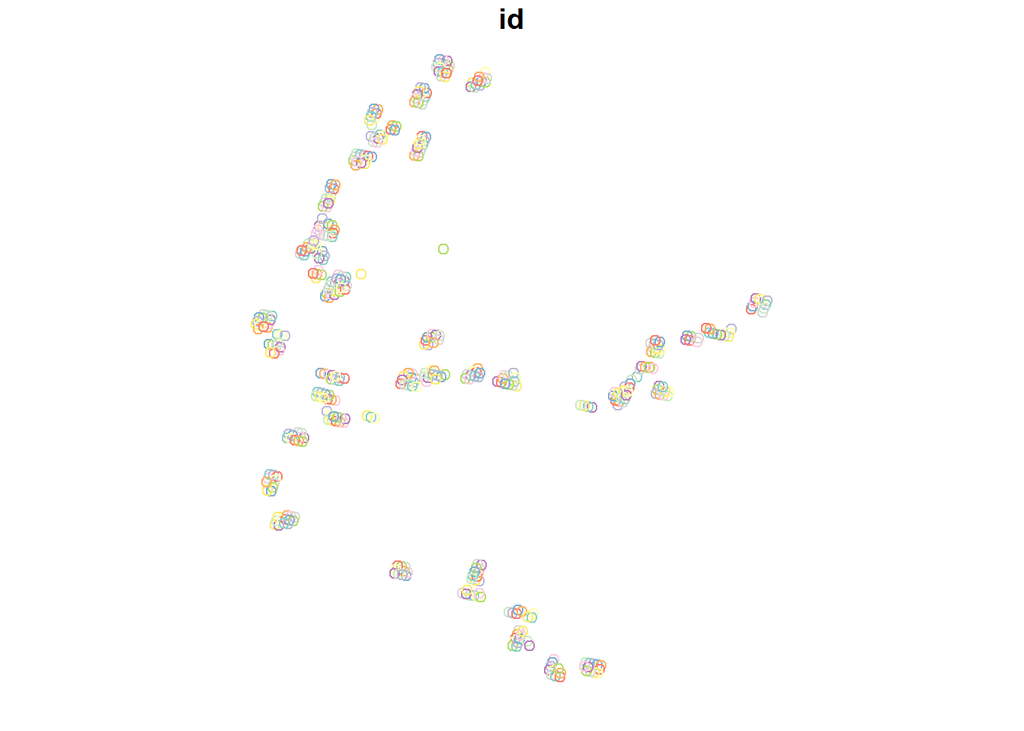

```r
plot(points21.proj)
```

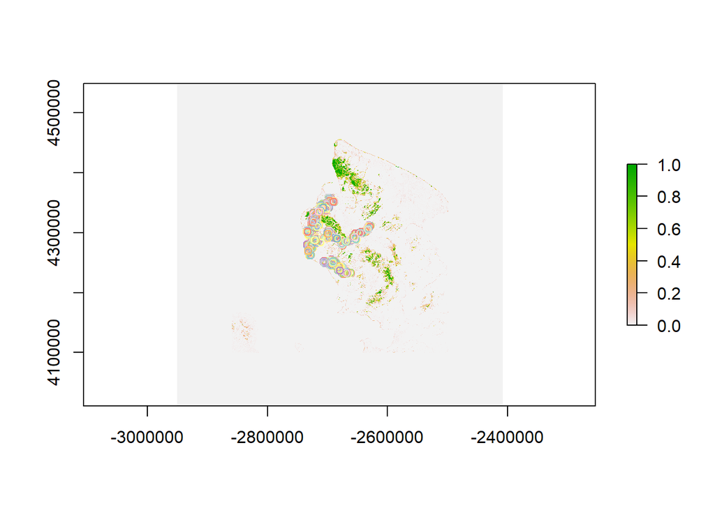

```r
# CHECK THAT ALL POINTS LOOK OKAY
plot(lc.stack[[1]])
plot(points19.proj, add = TRUE)
plot(points21.proj[1], add = TRUE)
```

## EXTRACT VALUES AT EACH SURVEY POINT

Since we have already calculated the percentage of land cover within a 390m buffer using the focal function, we can now just extract the values at each point without having to do another buffer/function.

1. Extract raster values at each point location

```r
lc.19 <- raster::extract(lc.stack, points19.proj)
lc.21 <- raster::extract(lc.stack, points21.proj)
```

2. Turn matrices into tables/dataframes and join with original point ids

```r
lc19.join <- as.data.frame(cbind(points19.proj, lc.19))
lc21.join <- as.data.frame(cbind(points21.proj, lc.21))
```

3. Merge (add) land cover types into specified groups

```r
# 2019
colnames(lc19.join)
```

```
##  [1] "id"        "barren"    "bog"       "decforest" "egforest"  "fen"
##  [7] "littoral"  "lowshrub"  "mixforest" "openshrub" "sparseveg" "tallshrub"
## [13] "tundra"    "tussock"   "water"     "woodland"  "geometry"
```

```r
lc19.join2 <- lc19.join %>%
  mutate(forest = egforest + decforest + mixforest + woodland,
         bare = barren + sparseveg,
         wetland = bog + fen + littoral)

# take out extra columns (ones that were added toether) and reorder
colnames(lc19.join2)
```

```
##  [1] "id"        "barren"    "bog"       "decforest" "egforest"  "fen"
##  [7] "littoral"  "lowshrub"  "mixforest" "openshrub" "sparseveg" "tallshrub"
## [13] "tundra"    "tussock"   "water"     "woodland"  "geometry"  "forest"
## [19] "bare"      "wetland"
```

```r
lc19.join3 <- lc19.join2[,c(1, 13, 14, 8, 12, 10, 19, 18, 20, 15)]
# 2021
colnames(lc21.join)
```

```
##  [1] "id"        "barren"    "bog"       "decforest" "egforest"  "fen"
##  [7] "littoral"  "lowshrub"  "mixforest" "openshrub" "sparseveg" "tallshrub"
## [13] "tundra"    "tussock"   "water"     "woodland"  "geometry"
```

```r
lc21.join2 <- lc21.join %>%
  mutate(forest = egforest + decforest + mixforest + woodland,
         bare = barren + sparseveg,
         wetland = bog + fen + littoral)

colnames(lc21.join2)
```

```
##  [1] "id"        "barren"    "bog"       "decforest" "egforest"  "fen"
##  [7] "littoral"  "lowshrub"  "mixforest" "openshrub" "sparseveg" "tallshrub"
## [13] "tundra"    "tussock"   "water"     "woodland"  "geometry"  "forest"
## [19] "bare"      "wetland"
```

```r
lc21.join3 <- lc21.join2[,c(1, 13, 14, 8, 12, 10, 19, 18, 20, 15)]
```

## EXPORT EXTRACTED LAND COVER VALUES

```r
write.csv(lc19.join3, here("data/landcover_19.csv"))
write.csv(lc21.join3, here("data/landcover_21.csv"))
```